# Análisis de Defunciones

2025-03-30

## Evolución de Defunciones por Año (Total)

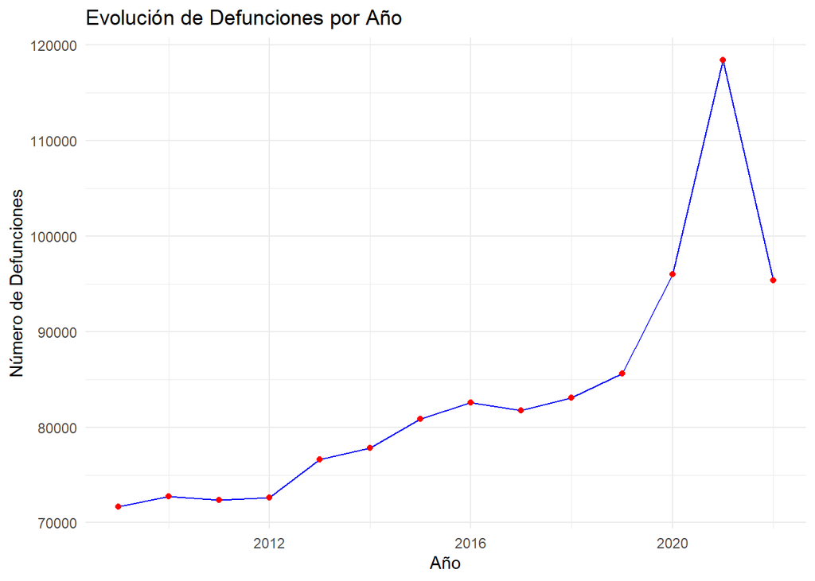

## Evolución de Defunciones por Causa (Top 5)

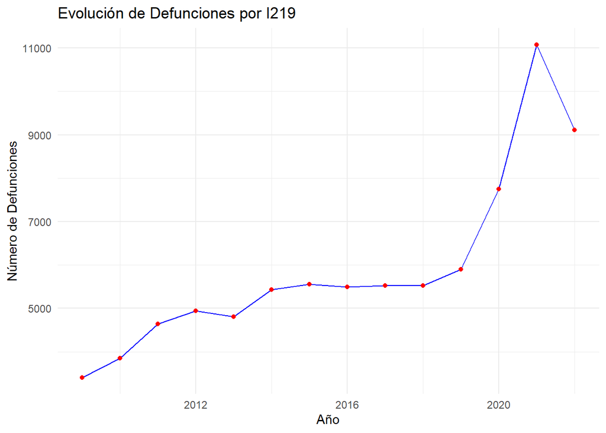

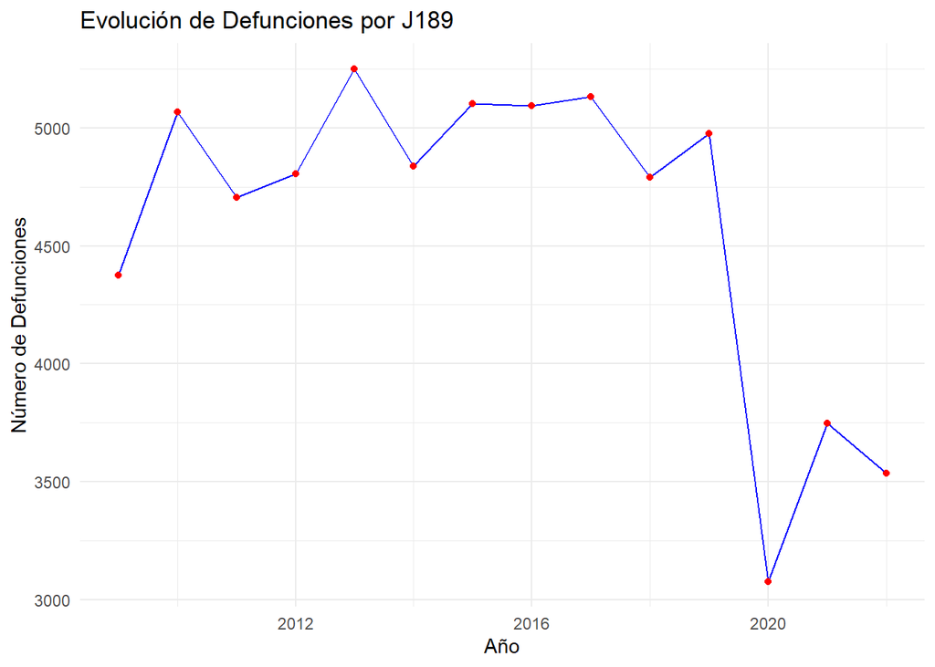

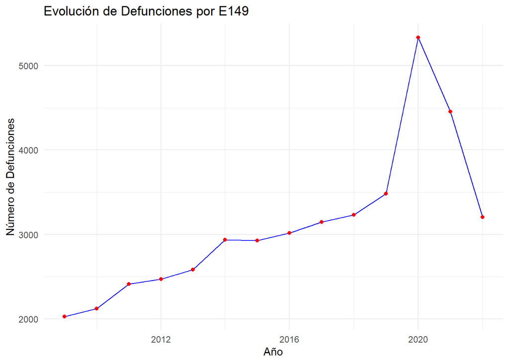

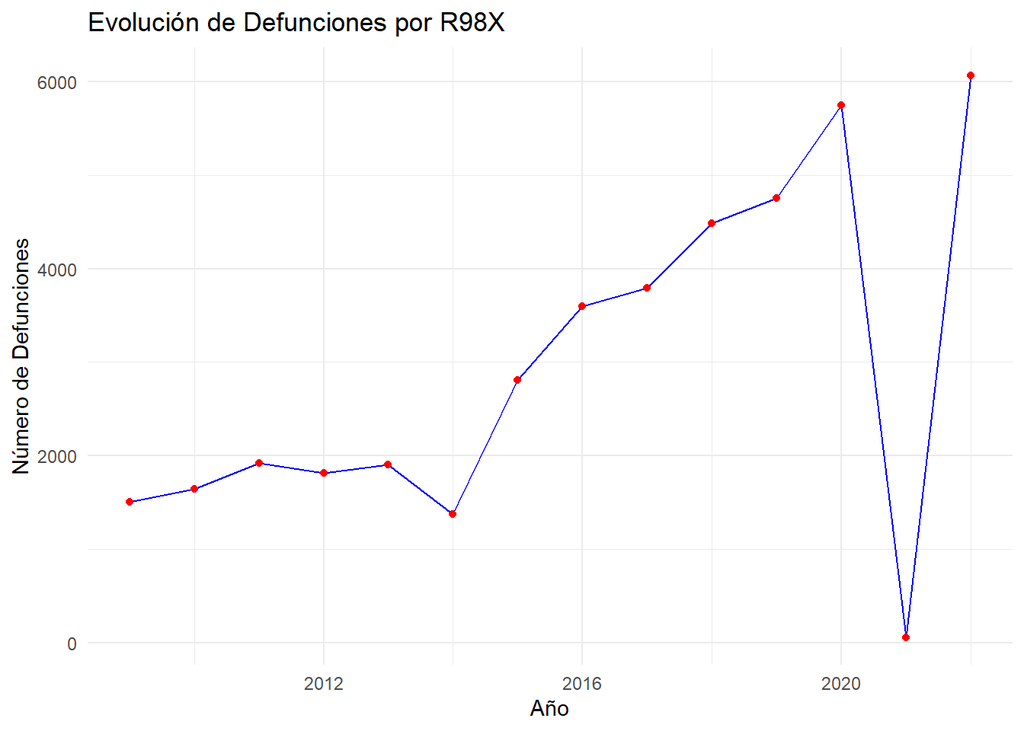

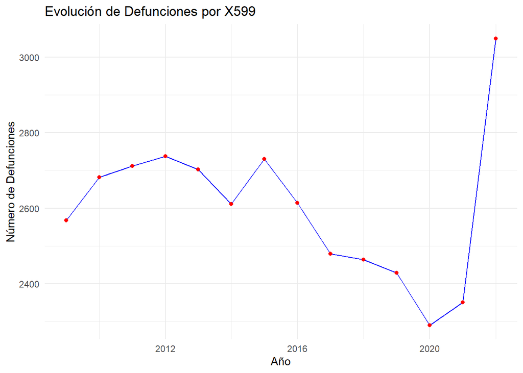

## Evolución de Defunciones por Sexo

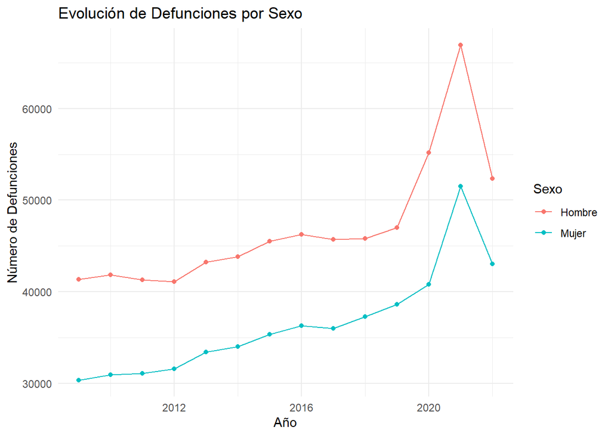

## Evolución de Defunciones por Estado Civil

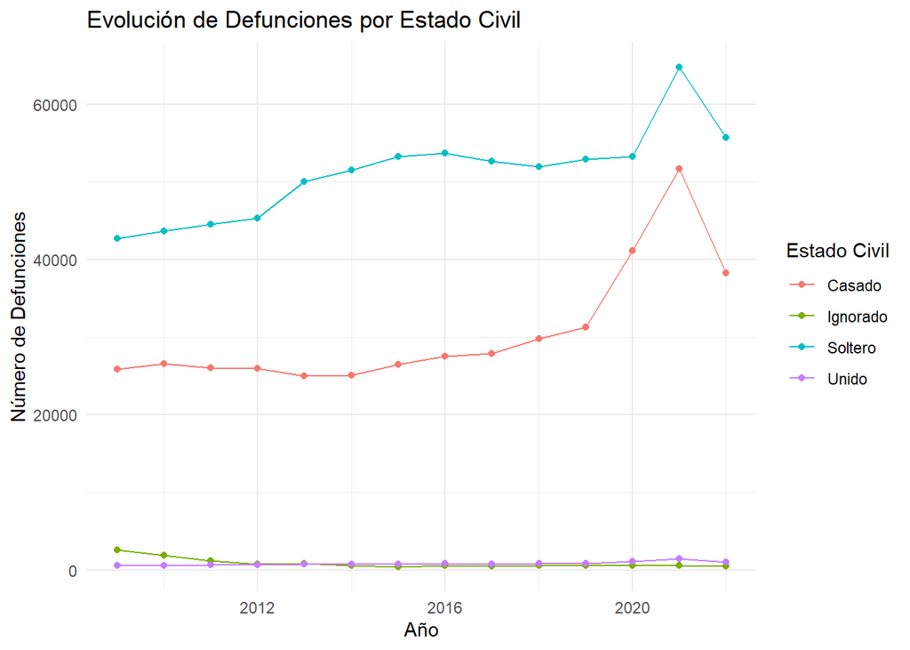

## Evolución de Defunciones por Escolaridad

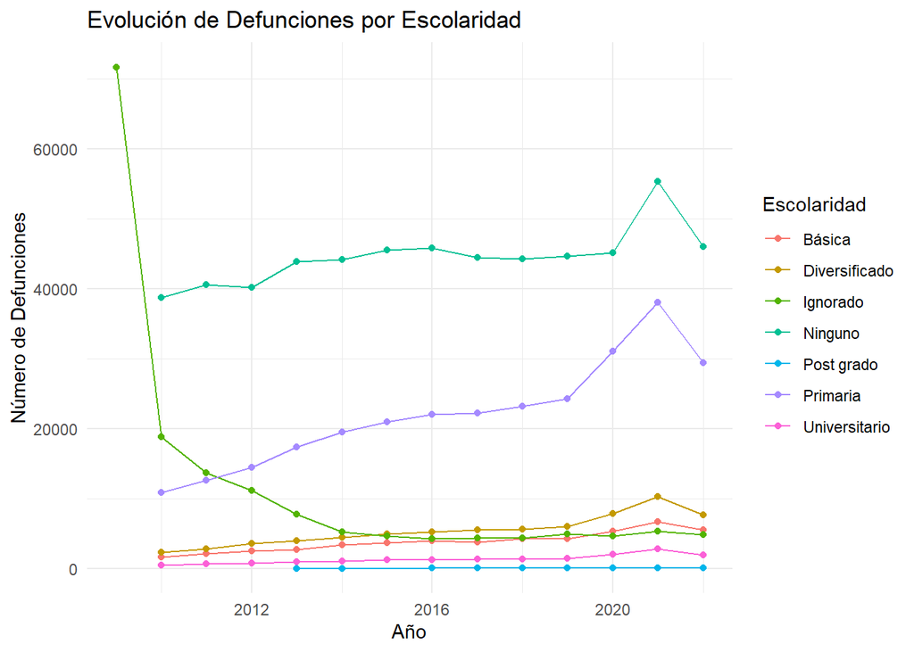

```
## # A tibble: 14 × 4
##    Año_ocurrencia Max_Edad Mediana_Edad Percentil_95
##             <int>    <int>        <dbl>        <dbl>
##  1           2009      100           54           81
##  2           2010      100           56           82
##  3           2011      100           57           83
##  4           2012      100           58           83
##  5           2013      100           59           83
##  6           2014      100           60           83
##  7           2015      100           59           84
##  8           2016      100           60           84
##  9           2017      100           61           84
## 10           2018      100           61           84
## 11           2019      100           62           84
## 12           2020      100           65           84
## 13           2021      100           65           84
## 14           2022      100           64           85
```

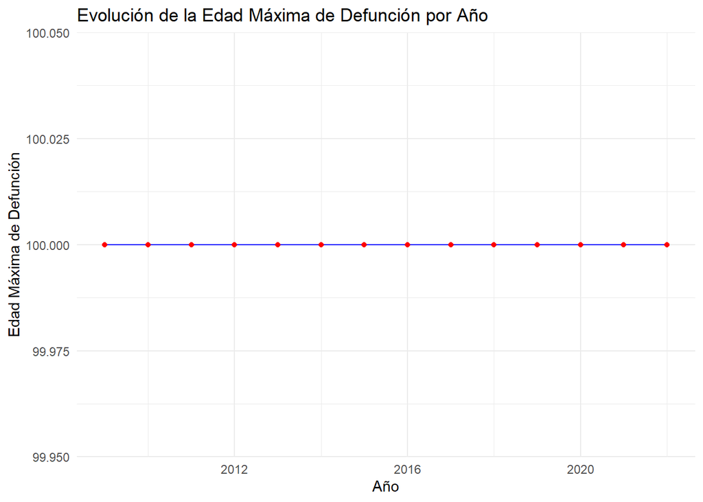

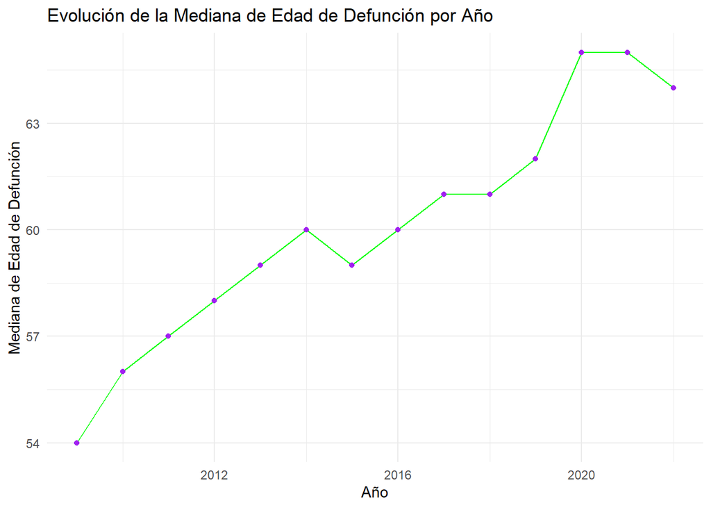

[figure not shown]

# Análisis Profundo de Factores Subyacentes

## 1. Tendencia Ascendente de Defunciones (2009-2022):

- **Envejecimiento de la Población:**
  - El aumento de la esperanza de vida, paradójicamente, puede llevar a un mayor número de defunciones, ya que una población envejecida es más susceptible a enfermedades crónicas y degenerativas.
  - Es crucial analizar la estructura de edad de la población para determinar si el aumento de defunciones se correlaciona con un envejecimiento poblacional significativo.
- **Cambios en los Estilos de Vida:**
  - La creciente prevalencia de estilos de vida sedentarios, dietas poco saludables y el consumo de tabaco y alcohol pueden aumentar el riesgo de enfermedades crónicas como enfermedades cardíacas, diabetes y cáncer.
  - Se debe investigar la disponibilidad de datos sobre hábitos de salud y factores de riesgo para evaluar su impacto en la mortalidad.
- **Prevalencia de Enfermedades Crónicas:**
  - El aumento de la incidencia de enfermedades crónicas como la diabetes, la hipertensión y el cáncer puede contribuir significativamente a la mortalidad.
  - Es esencial analizar las tendencias de prevalencia de estas enfermedades y su relación con las causas de muerte registradas.
- **Factores Socioeconómicos:**
  - La pobreza, la falta de acceso a la atención médica y la baja educación pueden aumentar el riesgo de mortalidad.
  - Se debe investigar la correlación entre la mortalidad y los indicadores socioeconómicos para identificar poblaciones vulnerables.
- **Factores Ambientales:**
  - La contaminación del aire, la exposición a sustancias tóxicas y el cambio climático pueden tener un impacto negativo en la salud y aumentar la mortalidad.
  - Es necesario analizar los datos referentes a la exposición de la población a estos factores, y la relación que pueda tener con los índices de mortalidad.
- **Acceso a la Atención Médica:**
  - Las desigualdades en el acceso a la atención médica de calidad pueden contribuir a una mayor mortalidad en ciertos grupos de población.
  - Se debe evaluar la disponibilidad y accesibilidad de los servicios de salud, especialmente para las poblaciones más vulnerables.

## 2. Evolución de Defunciones por Causa (Top 5):

- **I219 (Infarto Agudo del Miocardio):**
  - Factores de riesgo: hipertensión, colesterol alto, tabaquismo, diabetes, obesidad.
  - Estilos de vida: sedentarismo, mala alimentación, estrés.
  - Acceso a atención médica oportuna.
- **J189 (Neumonía no especificada):**
  - Factores ambientales: Contaminación del aire, cambios bruscos de temperatura.
  - Acceso a vacunación y tratamiento oportuno.
  - Condiciones de vida: Hacinamiento, falta de higiene.
- **E149 (Diabetes Mellitus):**
  - Factores genéticos.
  - Estilos de vida: mala alimentación, falta de ejercicio.
  - Acceso a diagnóstico temprano y tratamiento adecuado.
- **R98X (Muerte sin asistencia):**
  - Factores socioeconómicos: pobreza, falta de acceso a servicios de salud.
  - Factores culturales: rechazo a la atención médica.
  - Factores geográficos: áreas remotas con difícil acceso a servicios de emergencia.
- **X599 (Exposición a factores no especificados que causan otras lesiones y las no especificadas):**
  - Factores ambientales: Contaminación, desastres naturales.
  - Factores socioeconómicos: violencia, accidentes laborales.
  - Factores de seguridad: falta de medidas de prevención de accidentes.

# Análisis de Factores Subyacentes en la Mortalidad en Guatemala

## Evolución del Estilo de Vida, Dieta y Consumo de Sustancias:

- **Cambios en la Dieta:**
  - En Guatemala, como en muchos países en desarrollo, se observa una transición nutricional. Esto implica un aumento en el consumo de alimentos procesados, ricos en grasas saturadas, azúcares y sodio, y una disminución en el consumo de alimentos tradicionales como frutas, verduras y granos enteros.
  - Esta transición se relaciona con un aumento en la prevalencia de enfermedades crónicas no transmisibles (ECNT), como enfermedades cardíacas, diabetes y ciertos tipos de cáncer.
- **Sedentarismo:**
  - La urbanización y los cambios en los patrones laborales han llevado a un aumento del sedentarismo en la población guatemalteca.
  - La falta de actividad física regular aumenta el riesgo de obesidad, enfermedades cardíacas, diabetes y otras ECNT.
- **Consumo de Alcohol y Tabaco:**
  - El consumo de alcohol y tabaco sigue siendo un problema de salud pública en Guatemala.
  - Ambas sustancias son factores de riesgo importantes para enfermedades cardíacas, cáncer y otras enfermedades crónicas.
- **Hábitos de Salud y Factores de Riesgo:**
  - La falta de acceso a información y educación sobre hábitos de salud saludables contribuye a la prevalencia de factores de riesgo como la hipertensión, el colesterol alto y la obesidad.
  - Las barreras culturales y lingüísticas también pueden dificultar la adopción de hábitos de salud saludables en ciertas comunidades.

## Aumento de Enfermedades Crónicas:

- Las ECNT, incluyendo enfermedades cardíacas, diabetes y cáncer, están en aumento en Guatemala.
- Este aumento se relaciona con los cambios en el estilo de vida, la dieta y el consumo de sustancias mencionados anteriormente.
- La falta de acceso a la atención médica preventiva y el diagnóstico temprano también contribuyen a la carga de ECNT.

## Factores Socioeconómicos y Mortalidad:

- **Pobreza:**
  - La pobreza limita el acceso a alimentos nutritivos, agua potable, vivienda adecuada y servicios de salud, lo que aumenta el riesgo de enfermedades y muerte prematura.
  - Las personas que viven en la pobreza tienen más probabilidades de estar expuestas a factores de riesgo ambientales y laborales.
- **Falta de Acceso a la Atención Médica:**
  - Las desigualdades en el acceso a la atención médica de calidad son un problema importante en Guatemala.
  - Las poblaciones rurales e indígenas a menudo tienen dificultades para acceder a los servicios de salud debido a la distancia, el costo y las barreras culturales y lingüísticas.
- **Baja Educación:**
  - La baja educación se relaciona con una menor conciencia sobre los hábitos de salud saludables y un menor acceso a oportunidades económicas.
  - Las personas con baja educación tienen más probabilidades de tener trabajos de alto riesgo y de vivir en condiciones de pobreza.

## Población Más Vulnerable:

- Con base en la información anterior y los hallazgos, la población más vulnerable en Guatemala incluye:
  - Poblaciones rurales e indígenas: Estas poblaciones enfrentan múltiples barreras, incluyendo la pobreza, la falta de acceso a la atención médica y la baja educación.
  - Personas de bajos ingresos: La pobreza limita el acceso a alimentos nutritivos, vivienda adecuada y servicios de salud.
  - Personas con baja educación: La baja educación se relaciona con una menor conciencia sobre los hábitos de salud saludables y un menor acceso a oportunidades económicas.